# Netflix Movies and TV Shows

Melissa Webb

[figure not shown]

# Introduction to the data

This data set consists of listings of all the movies and TV shows available on Netflix (a video streaming service) as of September 2021.  
Here is a description of each of the columns in the data set:

- `show_id`: unique ID for every movie/show
- `type`: identifies if the row represents a movie or show
- `title`: title of the movie/show
- `director`: list of directors of the movie/show
- `cast`: list of actors in the movie/show
- `country`: countries where the movie/show was produced
- `date_added`: date the movie/show was added on Netflix
- `release_year`: year the movie/show was actually released
- `rating`: MPA rating of the movie/show
- `duration`: total duration in minutes for movies, or number of seasons for shows
- `listed_in`: list of genres the movie/show falls under
- `description`: summary description provided for the movie/show

## Loading and previewing the data

```r
library(tidyverse)
library(naniar)

nflx <- read.csv("netflix_titles.csv")
```

```r
head(nflx, 10)
```

|  | show_id | type | title | director | cast | country | date_added | release_year | rating | duration | listed_in | description |
| --- | --- | --- | --- | --- | --- | --- | --- | --- | --- | --- | --- | --- |
| 1 | s1 | Movie | Dick Johnson Is Dead | Kirsten Johnson |  | United States | September 25, 2021 | 2020 | PG-13 | 90 min | Documentaries | As her father nears the end of his life, filmmaker Kirsten Johnson stages his death in inventive and comical ways to help them both face the inevitable. |
| 2 | s2 | TV Show | Blood & Water |  | Ama Qamata, Khosi Ngema, Gail Mabalane, Thabang Molaba, Dillon Windvogel, Natasha Thahane, Arno Greeff, Xolile Tshabalala, Getmore Sithole, Cindy Mahlangu, Ryle De Morny, Greteli Fincham, Sello Maake … | South Africa | September 24, 2021 | 2021 | TV-MA | 2 Seasons | International TV Shows, TV Dramas, TV Mysteries | After crossing paths at a party, a Cape Town teen sets out to prove whether a private-school swimming star is her sister who was abducted at birth. |
| 3 | s3 | TV Show | Ganglands | Julien Leclercq | Sami Bouajila, Tracy Gotoas, Samuel Jouy, Nabiha Akkari, Sofia Lesaffre, Salim Kechiouche, Noureddine Farihi, Geert Van Rampelberg, Bakary Diombera |  | September 24, 2021 | 2021 | TV-MA | 1 Season | Crime TV Shows, International TV Shows, TV Action & Adventure | To protect his family from a powerful drug lord, skilled thief Mehdi and his expert team of robbers are pulled into a violent and deadly turf war. |
| 4 | s4 | TV Show | Jailbirds New Orleans |  |  |  | September 24, 2021 | 2021 | TV-MA | 1 Season | Docuseries, Reality TV | Feuds, flirtations and toilet talk go down among the incarcerated women at the Orleans Justice Center in New Orleans on this gritty reality series. |
| 5 | s5 | TV Show | Kota Factory |  | Mayur More, Jitendra Kumar, Ranjan Raj, Alam Khan, Ahsaas Channa, Revathi Pillai, Urvi Singh, Arun Kumar | India | September 24, 2021 | 2021 | TV-MA | 2 Seasons | International TV Shows, Romantic TV Shows, TV Comedies | In a city of coaching centers known to train Indiaâ\200\231s finest collegiate minds, an earnest but unexceptional student and his friends navigate campus life. |
| 6 | s6 | TV Show | Midnight Mass | Mike Flanagan | Kate Siegel, Zach Gilford, Hamish Linklater, Henry Thomas, Kristin Lehman, Samantha Sloyan, Igby Rigney, Rahul Kohli, Annarah Cymone, Annabeth Gish, Alex Essoe, Rahul Abburi, Matt Biedel, Michael Truc… |  | September 24, 2021 | 2021 | TV-MA | 1 Season | TV Dramas, TV Horror, TV Mysteries | The arrival of a charismatic young priest brings glorious miracles, ominous mysteries and renewed religious fervor to a dying town desperate to believe. |
| 7 | s7 | Movie | My Little Pony: A New Generation | Robert Cullen, JosÃ© Luis Ucha | Vanessa Hudgens, Kimiko Glenn, James Marsden, Sofia Carson, Liza Koshy, Ken Jeong, Elizabeth Perkins, Jane Krakowski, Michael McKean, Phil LaMarr |  | September 24, 2021 | 2021 | PG | 91 min | Children & Family Movies | Equestria's divided. But a bright-eyed hero believes Earth Ponies, Pegasi and Unicorns should be pals â\200” and, hoof to heart, sheâ\200\231s determined to prove it. |
| 8 | s8 | Movie | Sankofa | Haile Gerima | Kofi Ghanaba, Oyafunmike Ogunlano, Alexandra Duah, Nick Medley, Mutabaruka, Afemo Omilami, Reggie Carter, Mzuri | United States, Ghana, Burkina Faso, United Kingdom, Germany, Ethiopia | September 24, 2021 | 1993 | TV-MA | 125 min | Dramas, Independent Movies, International Movies | On a photo shoot in Ghana, an American model slips back in time, becomes enslaved on a plantation and bears witness to the agony of her ancestral past. |
| 9 | s9 | TV Show | The Great British Baking Show | Andy Devonshire | Mel Giedroyc, Sue Perkins, Mary Berry, Paul Hollywood | United Kingdom | September 24, 2021 | 2021 | TV-14 | 9 Seasons | British TV Shows, Reality TV | A talented batch of amateur bakers face off in a 10-week competition, whipping up their best dishes in the hopes of being named the U.K.'s best. |
| 10 | s10 | Movie | The Starling | Theodore Melfi | Melissa McCarthy, Chris O'Dowd, Kevin Kline, Timothy Olyphant, Daveed Diggs, Skyler Gisondo, Laura Harrier, Rosalind Chao, Kimberly Quinn, Loretta Devine, Ravi Kapoor | United States | September 24, 2021 | 2021 | PG-13 | 104 min | Comedies, Dramas | A woman adjusting to life after a loss contends with a feisty bird that's taken over her garden â\200” and a husband who's struggling to find a way forward. |

```r
dim(nflx)
```

```
## [1] 8807   12
```

The data set contains 8,807 rows and 12 columns. We will need to manipulate some of the columns to prepare them for data analysis.

## Data cleaning

### Setting desired columns

```r
# Dropping the description column
nflx_select <- nflx %>%
  select(-description)
```

```r
# Changing "listed_in" column to "genre"
colnames(nflx_select)
```

```
##  [1] "show_id"      "type"         "title"        "director"     "cast"
##  [6] "country"      "date_added"   "release_year" "rating"       "duration"
## [11] "listed_in"
```

```r
colnames(nflx_select)[11] <- "genre"
```

### Checking for duplicates

```r
# Checking for duplicates
count(unique(nflx_select["show_id"]))
```

| n |
| --- |
| 8807 |

```r
count(unique(nflx_select["title"]))
```

| n |
| --- |
| 8807 |

Both variables contain 8,807 unique values which matches the number of rows in the data set. Thus, there aren’t any duplicate observations.

### Handling missing values

```r
# Number of missing values by column
for(col in colnames(nflx_select)){
  total_missing <- sum(nflx_select[col] == "")
  cat(col, total_missing, "\n")
}
```

```
## show_id 0
## type 0
## title 0
## director 2634
## cast 825
## country 831
## date_added 10
## release_year 0
## rating 4
## duration 3
## genre 0
```

```r
# Replacing missing values with NA
nflx_na <- replace_with_na_all(nflx_select, condition = ~.x == "")

# Checking that they were replaced successfully
head(nflx_na, 10)
```

| show_id | type | title | director | cast | country | date_added | release_year | rating | duration | genre |
| --- | --- | --- | --- | --- | --- | --- | --- | --- | --- | --- |
| s1 | Movie | Dick Johnson Is Dead | Kirsten Johnson | NA | United States | September 25, 2021 | 2020 | PG-13 | 90 min | Documentaries |
| s2 | TV Show | Blood & Water | NA | Ama Qamata, Khosi Ngema, Gail Mabalane, Thabang Molaba, Dillon Windvogel, Natasha Thahane, Arno Greeff, Xolile Tshabalala, Getmore Sithole, Cindy Mahlangu, Ryle De Morny, Greteli Fincham, Sello Maake … | South Africa | September 24, 2021 | 2021 | TV-MA | 2 Seasons | International TV Shows, TV Dramas, TV Mysteries |
| s3 | TV Show | Ganglands | Julien Leclercq | Sami Bouajila, Tracy Gotoas, Samuel Jouy, Nabiha Akkari, Sofia Lesaffre, Salim Kechiouche, Noureddine Farihi, Geert Van Rampelberg, Bakary Diombera | NA | September 24, 2021 | 2021 | TV-MA | 1 Season | Crime TV Shows, International TV Shows, TV Action & Adventure |
| s4 | TV Show | Jailbirds New Orleans | NA | NA | NA | September 24, 2021 | 2021 | TV-MA | 1 Season | Docuseries, Reality TV |
| s5 | TV Show | Kota Factory | NA | Mayur More, Jitendra Kumar, Ranjan Raj, Alam Khan, Ahsaas Channa, Revathi Pillai, Urvi Singh, Arun Kumar | India | September 24, 2021 | 2021 | TV-MA | 2 Seasons | International TV Shows, Romantic TV Shows, TV Comedies |
| s6 | TV Show | Midnight Mass | Mike Flanagan | Kate Siegel, Zach Gilford, Hamish Linklater, Henry Thomas, Kristin Lehman, Samantha Sloyan, Igby Rigney, Rahul Kohli, Annarah Cymone, Annabeth Gish, Alex Essoe, Rahul Abburi, Matt Biedel, Michael Truc… | NA | September 24, 2021 | 2021 | TV-MA | 1 Season | TV Dramas, TV Horror, TV Mysteries |
| s7 | Movie | My Little Pony: A New Generation | Robert Cullen, JosÃ© Luis Ucha | Vanessa Hudgens, Kimiko Glenn, James Marsden, Sofia Carson, Liza Koshy, Ken Jeong, Elizabeth Perkins, Jane Krakowski, Michael McKean, Phil LaMarr | NA | September 24, 2021 | 2021 | PG | 91 min | Children & Family Movies |
| s8 | Movie | Sankofa | Haile Gerima | Kofi Ghanaba, Oyafunmike Ogunlano, Alexandra Duah, Nick Medley, Mutabaruka, Afemo Omilami, Reggie Carter, Mzuri | United States, Ghana, Burkina Faso, United Kingdom, Germany, Ethiopia | September 24, 2021 | 1993 | TV-MA | 125 min | Dramas, Independent Movies, International Movies |
| s9 | TV Show | The Great British Baking Show | Andy Devonshire | Mel Giedroyc, Sue Perkins, Mary Berry, Paul Hollywood | United Kingdom | September 24, 2021 | 2021 | TV-14 | 9 Seasons | British TV Shows, Reality TV |
| s10 | Movie | The Starling | Theodore Melfi | Melissa McCarthy, Chris O'Dowd, Kevin Kline, Timothy Olyphant, Daveed Diggs, Skyler Gisondo, Laura Harrier, Rosalind Chao, Kimberly Quinn, Loretta Devine, Ravi Kapoor | United States | September 24, 2021 | 2021 | PG-13 | 104 min | Comedies, Dramas |

```r
for(col in colnames(nflx_na)){
  total_missing <- sum(is.na(nflx_na[col]))
  cat(col, total_missing, "\n")
}
```

```
## show_id 0
## type 0
## title 0
## director 2634
## cast 825
## country 831
## date_added 10
## release_year 0
## rating 4
## duration 3
## genre 0
```

All missing values have been replaced with `NA`.

```r
# Confirming that there are only 2 types of media (Movie or TV Show)
unique(nflx_na["type"])
```

| type |
| --- |
| Movie |
| TV Show |

### Cleaning the `date_added` column

Let’s convert `date_added` from a character type to a date type.

```r
# Creating pattern that all `date_added` values should have
pattern <- "^[A-Za-z]+\\s\\d+,\\s\\d+$"

# Trimming whitespace from `date_added`
nflx_trim <- nflx_na %>%
  mutate(
    date_added = str_trim(date_added, side = "both")
  )

# Making sure that all dates in `date_added` are formatted the same way: "Month day#, year#"
nflx_trim %>%
  filter(
    !str_detect(date_added, pattern)
  )
```

| show_id | type | title | director | cast | country | date_added | release_year | rating | duration | genre |
| --- | --- | --- | --- | --- | --- | --- | --- | --- | --- | --- |

All dates are formatted the same way, so it’s safe to convert them.

```r
# Creating new column with dates stored as date type
nflx_date <- nflx_trim %>%
  mutate(
    date_added_as_date = as.Date(date_added, "%B %d, %Y")
  )

tail(select(nflx_date, date_added, date_added_as_date))
```

| date_added | date_added_as_date |
| --- | --- |
| March 9, 2016 | 2016-03-09 |
| November 20, 2019 | 2019-11-20 |
| July 1, 2019 | 2019-07-01 |
| November 1, 2019 | 2019-11-01 |
| January 11, 2020 | 2020-01-11 |
| March 2, 2019 | 2019-03-02 |

```r
# Dropping the old column, date_added
colnames(nflx_date)
```

```
##  [1] "show_id"            "type"               "title"
##  [4] "director"           "cast"               "country"
##  [7] "date_added"         "release_year"       "rating"
## [10] "duration"           "genre"              "date_added_as_date"
```

```r
nflx_date_drop <- select(nflx_date, -"date_added")

colnames(nflx_date_drop)
```

```
##  [1] "show_id"            "type"               "title"
##  [4] "director"           "cast"               "country"
##  [7] "release_year"       "rating"             "duration"
## [10] "genre"              "date_added_as_date"
```

### Cleaning the `rating` column

Next, let’s check out the `rating` column.

```r
unique(nflx_date_drop$rating)
```

```
##  [1] "PG-13"    "TV-MA"    "PG"       "TV-14"    "TV-PG"    "TV-Y"
##  [7] "TV-Y7"    "R"        "TV-G"     "G"        "NC-17"    "74 min"
## [13] "84 min"   "66 min"   "NR"       NA         "TV-Y7-FV" "UR"
```

We can see that values we would expect to be in the `duration` column (like “74 min”) are in the `ratings` column, so that will need to be investigated. Also, `NR` (Not Rated) and `UR` (Unrated) have the same meaning, so we will convert all `UR` ratings to `NR` for consistency purposes. Lastly, `NA` ratings may be updated.

```r
# Taking a closer look at ratings that have a duration as their value
nflx_date_drop %>%
  select(show_id, title, type, rating, duration) %>%
  filter(str_detect(rating, "min"))
```

| show_id | title | type | rating | duration |
| --- | --- | --- | --- | --- |
| s5542 | Louis C.K. 2017 | Movie | 74 min | NA |
| s5795 | Louis C.K.: Hilarious | Movie | 84 min | NA |
| s5814 | Louis C.K.: Live at the Comedy Store | Movie | 66 min | NA |

Note that these are the only films in the data set that have a missing value for `duration`. This is an error that can be corrected by replacing the `NA` values in `duration` with their corresponding values found in `rating`. According to Netflix, all three films are rated TV-MA, so we will input that information too.

```r
# Replacing NA values
nflx_duration <- nflx_date_drop

nflx_duration$duration[is.na(nflx_duration$duration)] <- nflx_duration$rating[is.na(nflx_duration$duration)]

nflx_duration %>%
  select(show_id, title, type, rating, duration) %>%
  filter(str_detect(rating, "min"))
```

| show_id | title | type | rating | duration |
| --- | --- | --- | --- | --- |
| s5542 | Louis C.K. 2017 | Movie | 74 min | 74 min |
| s5795 | Louis C.K.: Hilarious | Movie | 84 min | 84 min |
| s5814 | Louis C.K.: Live at the Comedy Store | Movie | 66 min | 66 min |

The `NA` values in `duration` have been replaced successfully. Now, let’s replace the ratings.

```r
# Storing show_id in preparation to replace corresponding ratings
filtered_show_id <- deframe(
  nflx_date_drop %>%
  filter(str_detect(rating, "min")) %>%
  select(show_id)
)

filtered_show_id
```

```
## [1] "s5542" "s5795" "s5814"
```

```r
# Replacing corresponding ratings with "TV-MA"
nflx_duration_rating <- nflx_duration

nflx_duration_rating$rating[nflx_duration_rating$show_id %in% filtered_show_id] <- "TV-MA"

nflx_duration_rating %>%
  select(show_id, title, type, rating, duration) %>%
  filter(show_id %in% filtered_show_id)
```

| show_id | title | type | rating | duration |
| --- | --- | --- | --- | --- |
| s5542 | Louis C.K. 2017 | Movie | TV-MA | 74 min |
| s5795 | Louis C.K.: Hilarious | Movie | TV-MA | 84 min |
| s5814 | Louis C.K.: Live at the Comedy Store | Movie | TV-MA | 66 min |

Now, we will convert all `UR` ratings to `NR`.

```r
# Identifying UR shows
nflx_duration_rating %>%
  select(show_id, title, type, rating) %>%
  filter(rating == "UR")
```

| show_id | title | type | rating |
| --- | --- | --- | --- |
| s7059 | Immoral Tales | Movie | UR |
| s7989 | Sex Doll | Movie | UR |
| s8791 | You Don't Mess with the Zohan | Movie | UR |

```r
nflx_rating <- nflx_duration_rating

# Converting ratings
nflx_rating$rating[nflx_rating$rating == "UR"] <- "NR"

nflx_rating %>%
  select(show_id, title, type, rating) %>%
  filter(show_id %in% c("s7059", "s7989", "s8791"))
```

| show_id | title | type | rating |
| --- | --- | --- | --- |
| s7059 | Immoral Tales | Movie | NR |
| s7989 | Sex Doll | Movie | NR |
| s8791 | You Don't Mess with the Zohan | Movie | NR |

The last step for this column is to investigate `NA` ratings.

```r
nflx_rating %>%
  select(show_id, title, type, rating) %>%
  filter(is.na(rating))
```

| show_id | title | type | rating |
| --- | --- | --- | --- |
| s5990 | 13TH: A Conversation with Oprah Winfrey & Ava DuVernay | Movie | NA |
| s6828 | Gargantia on the Verdurous Planet | TV Show | NA |
| s7313 | Little Lunch | TV Show | NA |
| s7538 | My Honor Was Loyalty | Movie | NA |

Four titles have `NA` ratings. We will replace their missing values for `rating` according to the ratings provided on [Netflix](https://www.netflix.com/browse) and [IMDB](https://www.imdb.com/).

```r
nflx_rating_na <- nflx_rating

nflx_rating_na$rating[is.na(nflx_rating_na$rating)] <- c("TV-PG", "TV-14", "TV-MA", "PG-13")

nflx_rating_na %>%
  select(show_id, title, type, rating) %>%
  filter(show_id %in% c("s5990","s6828","s7313","s7538"))
```

| show_id | title | type | rating |
| --- | --- | --- | --- |
| s5990 | 13TH: A Conversation with Oprah Winfrey & Ava DuVernay | Movie | TV-PG |
| s6828 | Gargantia on the Verdurous Planet | TV Show | TV-14 |
| s7313 | Little Lunch | TV Show | TV-MA |
| s7538 | My Honor Was Loyalty | Movie | PG-13 |

### Cleaning the `duration` column

```r
head(select(nflx_rating_na, type, duration), 10)
```

| type | duration |
| --- | --- |
| Movie | 90 min |
| TV Show | 2 Seasons |
| TV Show | 1 Season |
| TV Show | 1 Season |
| TV Show | 2 Seasons |
| TV Show | 1 Season |
| Movie | 91 min |
| Movie | 125 min |
| TV Show | 9 Seasons |
| Movie | 104 min |

The `duration` variable is counted in minutes for movies and by seasons for TV shows, so we will copy the values of `duration` into two separate columns (`movie_length` and `season_total`) to distinguish the two types of `duration`.

```r
# Creating two new columns
nflx_sep_durations <- nflx_rating_na %>%
  mutate(
    season_total = if_else(str_detect(duration, "Season"), as.integer(parse_number(duration)), NA_integer_),
    movie_length = if_else(str_detect(duration, "min"), as.integer(parse_number(duration)), NA_integer_)
  )

# Checking that the columns were created successfully
nflx_sep_durations %>%
  select(type, duration, season_total, movie_length)
```

| type | duration | season_total | movie_length |
| --- | --- | --- | --- |
| Movie | 90 min | NA | 90 |
| TV Show | 2 Seasons | 2 | NA |
| TV Show | 1 Season | 1 | NA |
| TV Show | 1 Season | 1 | NA |
| TV Show | 2 Seasons | 2 | NA |
| TV Show | 1 Season | 1 | NA |
| Movie | 91 min | NA | 91 |
| Movie | 125 min | NA | 125 |
| TV Show | 9 Seasons | 9 | NA |
| Movie | 104 min | NA | 104 |

[output cut: 8797 more lines]

```r
# Dropping the original column
nflx_clean <- select(nflx_sep_durations, -duration)

colnames(nflx_clean)
```

```
##  [1] "show_id"            "type"               "title"
##  [4] "director"           "cast"               "country"
##  [7] "release_year"       "rating"             "genre"
## [10] "date_added_as_date" "season_total"       "movie_length"
```

## Data visualization

### Number of movies vs TV shows

```r
content_type <- count(nflx_clean, type)

content_type
```

| type | n |
| --- | --- |
| Movie | 6131 |
| TV Show | 2676 |

We can see that the majority of content available on Netflix are movies.

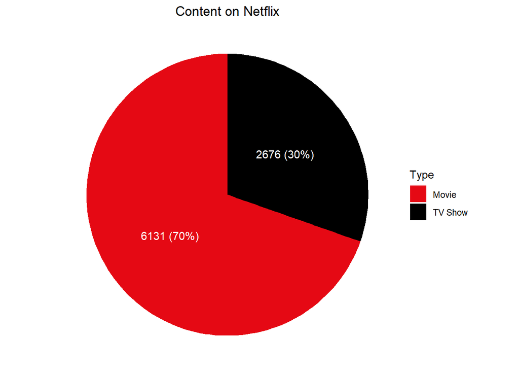

```r
# Visualizing Netflix content via pie chart
content_type %>%
  ggplot(aes(x = "", y = n, fill = type)) +
  geom_bar(stat = "identity") +
  coord_polar(theta = "y") +
  labs(
    title = "Content on Netflix",
    fill = "Type"
    ) +
  geom_text(
    aes(label = paste0(n," (",scales::percent(n / sum(n)),")")),
    position = position_stack(vjust = 0.5),
    color = "white"
    ) +
  theme_void() +
  theme(plot.title = element_text(hjust = 0.5)) +
  scale_fill_manual(
    breaks = c("Movie", "TV Show"),
    values=c("#E50914", "black")
    )
```

Roughly 70% of the content available on Netflix are movies.

### Countries where content on Netflix is produced

Let’s identify the top 10 countries where content available on Netflix is produced.

```r
# Extracting column of interest, "country"
countries <- nflx_clean["country"]

glimpse(countries)
```

```
## Rows: 8,807
## Columns: 1
## $ country <chr> "United States", "South Africa", NA, NA, "India", NA, NA, "Uni~
```

```r
# Drop rows where country is NA
countries <- drop_na(countries)
```

Some rows contain more than one country. We will need to manipulate the data frame so that each row contains only one country. This will be accomplished by creating a new column.

```r
# Separating countries into individual rows in new column, country_2
countries_split <- countries %>%
  mutate(country_2 = strsplit(country, ",")) %>%
  unnest(country_2) %>%
  mutate(country_2 = str_trim(country_2))

head(countries_split, 10)
```

| country | country_2 |
| --- | --- |
| United States | United States |
| South Africa | South Africa |
| India | India |
| United States, Ghana, Burkina Faso, United Kingdom, Germany, Ethiopia | United States |
| United States, Ghana, Burkina Faso, United Kingdom, Germany, Ethiopia | Ghana |
| United States, Ghana, Burkina Faso, United Kingdom, Germany, Ethiopia | Burkina Faso |
| United States, Ghana, Burkina Faso, United Kingdom, Germany, Ethiopia | United Kingdom |
| United States, Ghana, Burkina Faso, United Kingdom, Germany, Ethiopia | Germany |
| United States, Ghana, Burkina Faso, United Kingdom, Germany, Ethiopia | Ethiopia |
| United Kingdom | United Kingdom |

```r
# Dropping old column, country
countries_split_clean <- countries_split %>%
  select(country_2) %>%
  rename(country = country_2)
```

```r
# Getting number of movies/shows produced in each country
country_count <- count(countries_split_clean, country)

tail(country_count)
```

| country | n |
| --- | --- |
| Uruguay | 14 |
| Vatican City | 1 |
| Venezuela | 4 |
| Vietnam | 7 |
| West Germany | 5 |
| Zimbabwe | 3 |

Now, let’s identify the top 10 countries.

```r
# Arranging countries by number and keeping the top 10
country_top_10 <- arrange(country_count, -n) %>% head(10)

country_top_10
```

| country | n |
| --- | --- |
| United States | 3690 |
| India | 1046 |
| United Kingdom | 806 |
| Canada | 445 |
| France | 393 |
| Japan | 318 |
| Spain | 232 |
| South Korea | 231 |
| Germany | 226 |
| Mexico | 169 |

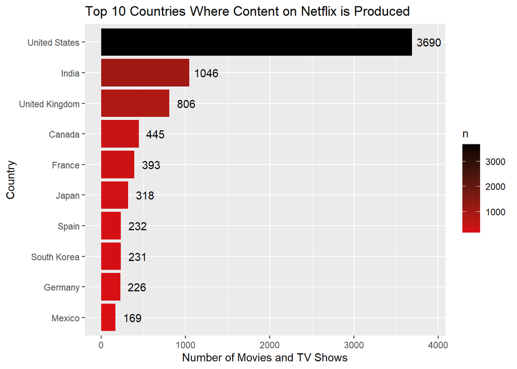

```r
# Bar chart for top 10 countries
country_top_10 %>%
  ggplot(aes(x = reorder(country, +n), y = n)) +
  geom_col(aes(fill = n)) +
  coord_flip() +
  scale_fill_gradient2(low='white', mid='#E50914', high='black') +
  labs(
    title = "Top 10 Countries Where Content on Netflix is Produced",
    x = "Country",
    y = "Number of Movies and TV Shows"
  ) +
  geom_text(aes(label = n), nudge_y = 200)
```

We can see that the United States takes the top position with 3,690 movies/TV shows. Mexico takes the tenth spot with 169 shows.

### Tracking shows added by date

Let’s observe the rate at which Netflix has expanded its catalog throughout the years.

```r
# Extracting date added
date_added <- drop_na(nflx_clean["date_added_as_date"])
```

We only need the year each title was added to Netflix, so we will extract that information from the `date_added_as_date` column and calculate the number of titles added each year.

```r
# Creating new column containing year only
date_year_added <- date_added %>%
  rename(date = date_added_as_date) %>%
  mutate(year = format(date, "%Y"))

head(date_year_added)
```

| date | year |
| --- | --- |
| 2021-09-25 | 2021 |
| 2021-09-24 | 2021 |
| 2021-09-24 | 2021 |
| 2021-09-24 | 2021 |
| 2021-09-24 | 2021 |
| 2021-09-24 | 2021 |

```r
# df containing number of movies/shows added to Netflix each year
year_count <- count(date_year_added, year)

year_count
```

| year | n |
| --- | --- |
| 2008 | 2 |
| 2009 | 2 |
| 2010 | 1 |
| 2011 | 13 |
| 2012 | 3 |
| 2013 | 11 |
| 2014 | 24 |
| 2015 | 82 |
| 2016 | 429 |
| 2017 | 1188 |

[output cut: 4 more lines]

The number of titles released generally appear to be increasing from year-to-year. Let’s visualize the data to make this clearer.

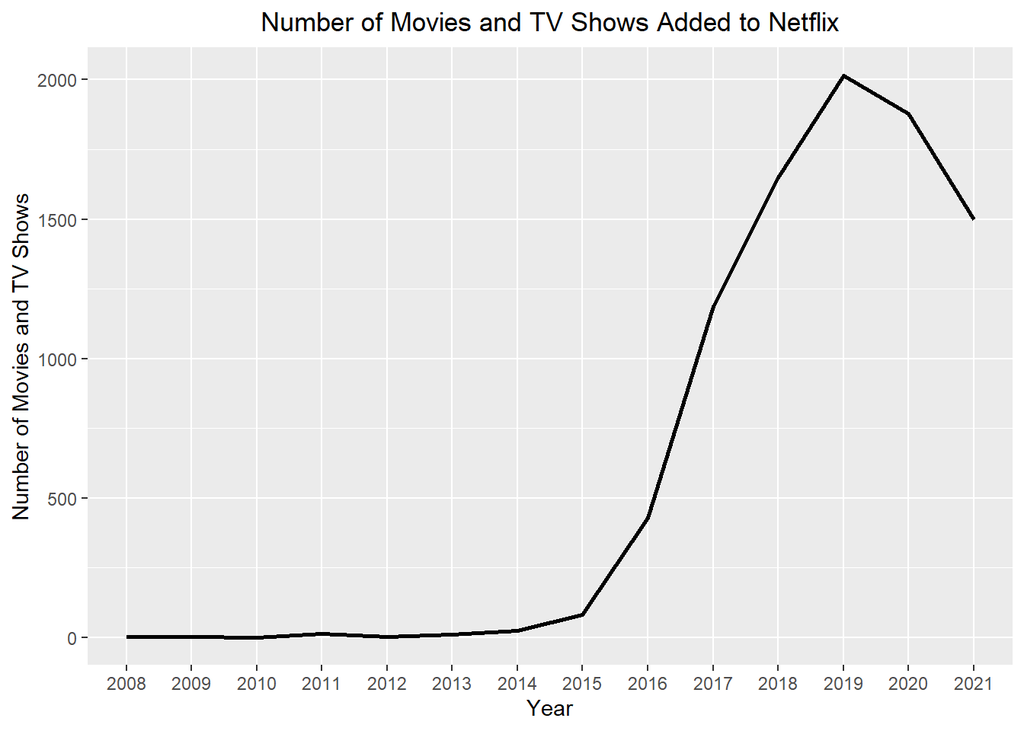

```r
# Line graph of number of movies/shows added each year
year_count %>%
  ggplot(aes(x = year, y = n, group = 1)) +
  geom_line(size = 1) +
  labs(
    title = "Number of Movies and TV Shows Added to Netflix",
    x = "Year",
    y = "Number of Movies and TV Shows"
  ) +
  theme(plot.title = element_text(hjust = 0.5))
```

In 2017, we see more than double the amount of content added compared to 2016. This may be partly attributed to Netflix releasing more original content in 2017. We also observe an upward trend from 2013 to 2019, and then a slight decrease in 2020 which we can speculate is due to the COVID-19 pandemic which halted production of movies and TV shows that year. It will be interesting to see how much content is added to the streaming service in 2022.

### Identifying the target audience

We will look at the ratings that are most popular on Netflix.

```r
# Getting and arranging ratings by number of occurrences
rating_count <- count(nflx_clean, rating)

arrange(rating_count, -n)
```

| rating | n |
| --- | --- |
| TV-MA | 3211 |
| TV-14 | 2161 |
| TV-PG | 864 |
| R | 799 |
| PG-13 | 491 |
| TV-Y7 | 334 |
| TV-Y | 307 |
| PG | 287 |
| TV-G | 220 |
| NR | 83 |

[output cut: 3 more lines]

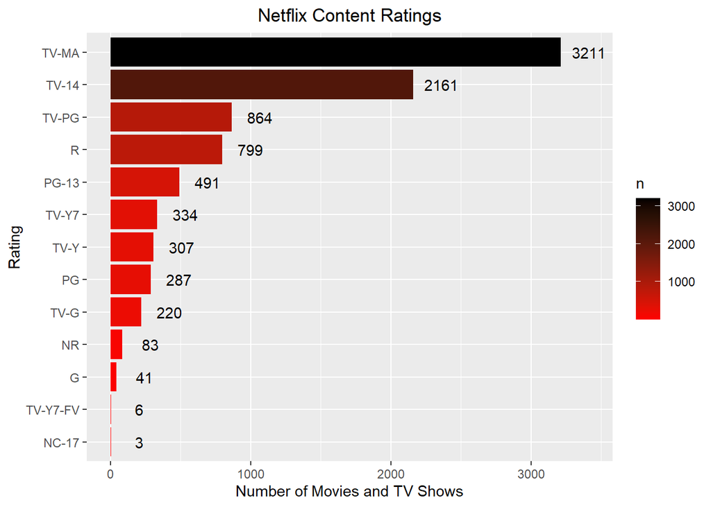

```r
# Bar chart for ratings
rating_count %>%
  ggplot(aes(x = reorder(rating, +n), y = n)) +
  geom_col(aes(fill = n)) +
  coord_flip()+
  scale_fill_gradient2(low='white', mid='red', high='black') +
  labs(
    title = "Netflix Content Ratings",
    x = "Rating",
    y = "Number of Movies and TV Shows"
  ) +
  geom_text(aes(label = n), nudge_y = 200) +
  theme(plot.title = element_text(hjust = 0.5))
```

The most popular rating is TV-MA which signifies content that is for mature audiences. This suggests that Netflix primarily caters to adult users.

We can take a more general look at the type of content available on Netflix by placing each rating into one of the following broad categories:

- Kid (TV-Y, TV-Y7, TV-Y7-FV, TV-G, G)
- Teen (TV-PG, TV-14, PG, PG-13)
- Adult (TV-MA, NC-17, R)

```r
# Categorizing ratings
rating_count_category <- rating_count %>%
  filter(rating != "NR") %>%
  mutate(
    category = case_when(str_detect(rating, "PG|TV-14") ~ "Teen",
                         str_detect(rating, "Y|TV-G|G") ~ "Kid",
                         TRUE ~ "Adult")
  )

rating_count_category
```

| rating | n | category |
| --- | --- | --- |
| G | 41 | Kid |
| NC-17 | 3 | Adult |
| PG | 287 | Teen |
| PG-13 | 491 | Teen |
| R | 799 | Adult |
| TV-14 | 2161 | Teen |
| TV-G | 220 | Kid |
| TV-MA | 3211 | Adult |
| TV-PG | 864 | Teen |
| TV-Y | 307 | Kid |

[output cut: 2 more lines]

```r
# Grouping ratings by category and calculating sum
rating_category <- rating_count_category %>%
  group_by(category) %>%
  summarize(
    total = sum(n)
  )

rating_category
```

| category | total |
| --- | --- |
| Adult | 4013 |
| Kid | 908 |
| Teen | 3803 |

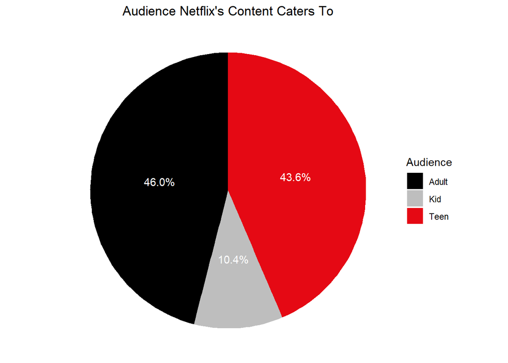

```r
# Visualizing ratings via pie chart
rating_category %>%
  ggplot(aes(x = "", y = total, fill = category)) +
  geom_bar(stat = "identity") +
  coord_polar(theta = "y") +
  theme_void() +
  labs(
    title = "Audience Netflix's Content Caters To",
    fill = "Audience"
    ) +
  theme(plot.title = element_text(hjust = 0.5)) +
  scale_fill_manual(
    breaks = c("Adult", "Kid", "Teen"),
    values=c("black", "gray", "#E50914")
    ) +
  geom_text(
    aes(label = scales::percent(total / sum(total))),
    position = position_stack(vjust = 0.5),
    color = "white"
    )
```